# chapter5.Rmd

Keegan

2022-12-06

# Assignment 5

First let’s load up the data we’ll need.

```r
library(dplyr)
human <- read.table("https://raw.githubusercontent.com/KimmoVehkalahti/Helsinki-Open-Data-Science/master/datasets/human2.txt", sep = ",", header = T)
```

We’ve narrowed the data down in our data wrangling exercise. This data comes from the UN Development Program’s Human Development Index (HDI), and it has been paired down to simplify some of the missing pieces in the data.

## 1 Show a graphical overview of the data

Let’s take a look at what’s inside our data file ‘human’

```r
library(GGally)
```

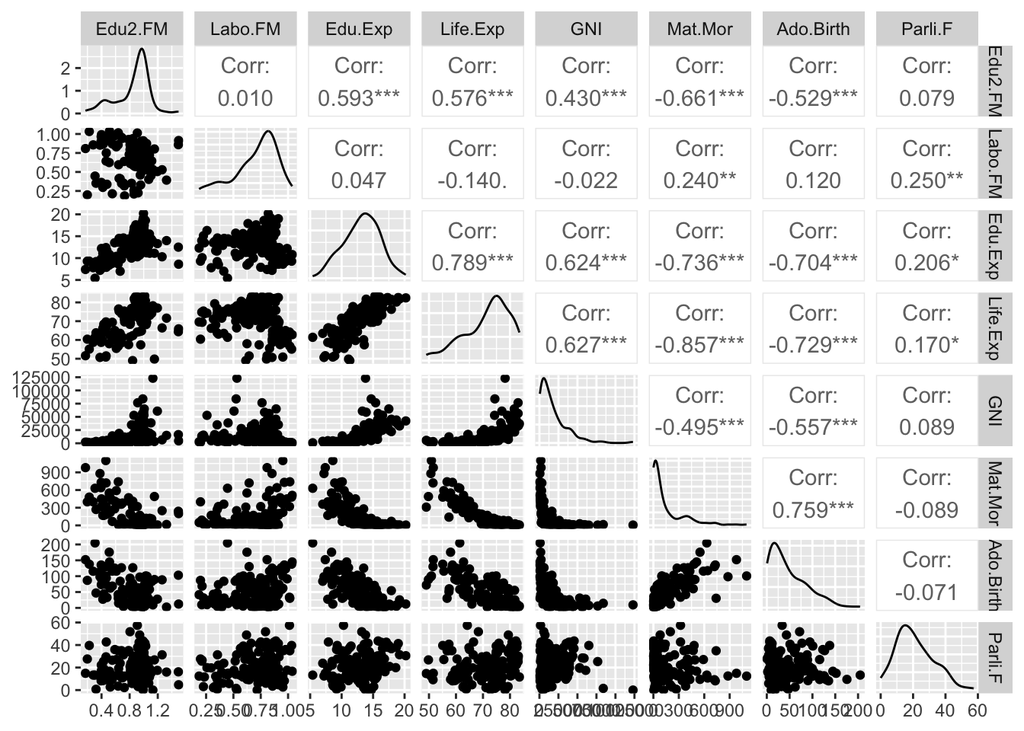

```r
ggpairs(human)
```

Here we can see lots of interesting correlations in our data set. For example, note the strong correlation between variables like life expectancy, and the expected number of years of education.

```r
summary(human)
```

```
##     Edu2.FM          Labo.FM          Edu.Exp         Life.Exp
##  Min.   :0.1717   Min.   :0.1857   Min.   : 5.40   Min.   :49.00
##  1st Qu.:0.7264   1st Qu.:0.5984   1st Qu.:11.25   1st Qu.:66.30
##  Median :0.9375   Median :0.7535   Median :13.50   Median :74.20
##  Mean   :0.8529   Mean   :0.7074   Mean   :13.18   Mean   :71.65
##  3rd Qu.:0.9968   3rd Qu.:0.8535   3rd Qu.:15.20   3rd Qu.:77.25
##  Max.   :1.4967   Max.   :1.0380   Max.   :20.20   Max.   :83.50
##       GNI            Mat.Mor         Ado.Birth         Parli.F
##  Min.   :   581   Min.   :   1.0   Min.   :  0.60   Min.   : 0.00
##  1st Qu.:  4198   1st Qu.:  11.5   1st Qu.: 12.65   1st Qu.:12.40
##  Median : 12040   Median :  49.0   Median : 33.60   Median :19.30
##  Mean   : 17628   Mean   : 149.1   Mean   : 47.16   Mean   :20.91
##  3rd Qu.: 24512   3rd Qu.: 190.0   3rd Qu.: 71.95   3rd Qu.:27.95
##  Max.   :123124   Max.   :1100.0   Max.   :204.80   Max.   :57.50
```

Looking again at life expectancy, we can also see that the minimum average life expectancy is 49 years, while the maximum is 83.5.

## 2. Perform principal component analysis (PCA)

We will now use principle component analysis on the data, and summarize the findings.

### principal component analysis for unscaled data

First, we will take a look at the results using unscaled data.

```r
pca_human <- prcomp(human)

pca_summary <- summary(pca_human)

pca_summary
```

```
## Importance of components:
##                              PC1      PC2   PC3   PC4   PC5   PC6    PC7    PC8
## Standard deviation     1.854e+04 185.5219 25.19 11.45 3.766 1.566 0.1912 0.1591
## Proportion of Variance 9.999e-01   0.0001  0.00  0.00 0.000 0.000 0.0000 0.0000
## Cumulative Proportion  9.999e-01   1.0000  1.00  1.00 1.000 1.000 1.0000 1.0000
```

### Draw a biplot displaying the observations

Below we have created a biplot where, the first principle component is on the x-axis, and the second is on the y-axis.

```r
pca_percent <- round(1*pca_summary$importance[2, ], digits = 5)

pca_percent
```

```
##    PC1    PC2    PC3    PC4    PC5    PC6    PC7    PC8
## 0.9999 0.0001 0.0000 0.0000 0.0000 0.0000 0.0000 0.0000
```

[figure not shown]

```r
pc_lab <- paste0(names(pca_percent), " (", pca_percent, "%)")

biplot(pca_human, cex = c(0.8, 1), col = c("grey40", "deeppink2"), xlab = pc_lab[1], ylab = pc_lab[2])
```

## 3. Standardize the variables in the human data and repeat the above analysis

We will now perform the same operation, but this time we will standardize the variable, so that they are more easily comparable

```r
human_standard <- scale(human)

pca_human_standard <- prcomp(human_standard)

summary_human_standard <- summary(pca_human_standard)

summary_human_standard
```

```
## Importance of components:
##                          PC1    PC2     PC3     PC4     PC5     PC6     PC7
## Standard deviation     2.071 1.1397 0.87505 0.77886 0.66196 0.53631 0.45900
## Proportion of Variance 0.536 0.1624 0.09571 0.07583 0.05477 0.03595 0.02634
## Cumulative Proportion  0.536 0.6984 0.79413 0.86996 0.92473 0.96069 0.98702
##                            PC8
## Standard deviation     0.32224
## Proportion of Variance 0.01298
## Cumulative Proportion  1.00000
```

```r
pca_percent_standard <- round(1*summary_human_standard$importance[2, ], digits = 5)

pca_percent_standard
```

```
##     PC1     PC2     PC3     PC4     PC5     PC6     PC7     PC8
## 0.53605 0.16237 0.09571 0.07583 0.05477 0.03595 0.02634 0.01298
```

[figure not shown]

```r
pc_lab_standard <- paste0(names(pca_percent_standard), " (", pca_percent_standard, "%)")

biplot(pca_human_standard, cex = c(0.8, 1), col = c("grey40", "deeppink2"), xlab = pc_lab_standard[1], ylab = pc_lab_standard[2])
```

Variables like life expectancy, expected years of education, and education experience, all go together nicely, as one might expect, while maternal mortality and adolescent birth rate go together, but in the opposite direction.